# Predicting Raw COMPAS scores with Charges

Beau Coker

6/27/2018

```r
library(lubridate)
library(xgboost)
library(randomForest)
library(tidyverse)
library(magrittr)
library(segmented)
source('functions.r')

load("Table_construction.Rdata")
set.seed(12)
```

```r
features = features %>%
  # Add other useful information:
  inner_join(
    data_before %>%
      select(person_id, screening_date, people) %>%
      unnest() %>%
      select(person_id, screening_date, race, sex, name),
    by = c("person_id","screening_date")
  ) %>%
  inner_join(features_on, by = c("person_id","screening_date")) %>%
  inner_join(outcomes, by = c("person_id","screening_date")) %>%
    # select(-c(offenses_within_30.y)) %>%

  # Create as many features as possible:
  mutate(
    raw_score = `Risk of Recidivism_raw_score`, # Adjust for violent/general
    decile_score = `Risk of Recidivism_decile_score`, # Adjust for violent/general
    p_jail30 = pmin(p_jail30,5),
    p_prison30 = pmin(p_jail30,5),
    p_prison = pmin(p_prison,5),
    p_probation = pmin(p_probation,5),
    race_black = if_else(race=="African-American",1,0),
    race_white = if_else(race=="Caucasian",1,0),
    race_hispanic = if_else(race=="Hispanic",1,0),
    race_asian = if_else(race=="Asian",1,0),
    race_native = if_else(race=="Native American",1,0), # race == "Other" is the baseline

    # Subscales:
    crim_inv = p_charge+
               p_jail30+
               p_prison+
               p_probation,

    # Filters (TRUE for obserations to keep)
    filt1 = `Risk of Recidivism_decile_score` != -1, `Risk of Violence_decile_score` != -1,
    filt2 = offenses_within_30 == 1,
    filt3 = !is.na(current_offense_date),
    filt4 = current_offense_date <= current_offense_date_limit,
    filt5 = p_current_age > 18 & p_current_age <= 65,
    filt6 = crim_inv == 0
  )
```

Modelling the COMPAS Risk of Recidivism score with a quadratic poly.

```r
#filter out any individuals with crim inv history
features_age_poly = features %>%
  filter(filt1,filt5, filt6)

lb_age = features_age_poly %>%
  group_by(p_current_age) %>%
  arrange(raw_score) %>%
  top_n(n=-1, wt=raw_score) # Fit lower bound on smallest value for each age

mdl_age = lm(raw_score ~
               I(p_current_age^2) +
               p_current_age,
             data=lb_age)

# More precision for paper
summary(mdl_age)
```

```
##
## Call:
## lm(formula = raw_score ~ I(p_current_age^2) + p_current_age,
##     data = lb_age)
##
## Residuals:
##      Min       1Q   Median       3Q      Max
## -0.22772 -0.01663  0.01004  0.02784  0.14974
##
## Coefficients:
##                      Estimate Std. Error t value Pr(>|t|)
## (Intercept)        -3.580e-02  6.114e-02  -0.586     0.56
## I(p_current_age^2)  4.634e-04  3.664e-05  12.646   <2e-16 ***
## p_current_age      -7.480e-02  3.096e-03 -24.161   <2e-16 ***
## ---
## Signif. codes:  0 '***' 0.001 '**' 0.01 '*' 0.05 '.' 0.1 ' ' 1
##
## Residual standard error: 0.05025 on 93 degrees of freedom
## Multiple R-squared:  0.9879, Adjusted R-squared:  0.9877
## F-statistic:  3806 on 2 and 93 DF,  p-value: < 2.2e-16
```

```r
print("Coefficients:")
```

```
## [1] "Coefficients:"
```

```r
sprintf("%.20e",mdl_age$coefficients) # More precision for paper
```

```
## [1] "-3.58034341549837223373e-02" "4.63390462694484011469e-04"
## [3] "-7.48013245320391095827e-02"
```

```r
## Add f(age) to features
features = features %>%
  mutate(
    f_age = predict(mdl_age, newdata=data.frame(p_current_age=p_current_age)),
    raw_score__age_poly = raw_score - f_age,
    filt7 = raw_score >= f_age - 0.05
  )
## Add same filters to lb_age
lb_age = lb_age %>%
    mutate(
    f_age = predict(mdl_age, newdata=data.frame(p_current_age=p_current_age)),
    raw_score__age_poly = raw_score - f_age,
    filt7 = raw_score >= f_age - 0.05
    )
```

Plotting settings

```r
xmin = 18
xmax = 65
xx = seq(xmin,xmax, length.out = 1000)
```

## Age polynomial plot

Generate a preliminary plot of age vs COMPAS general score

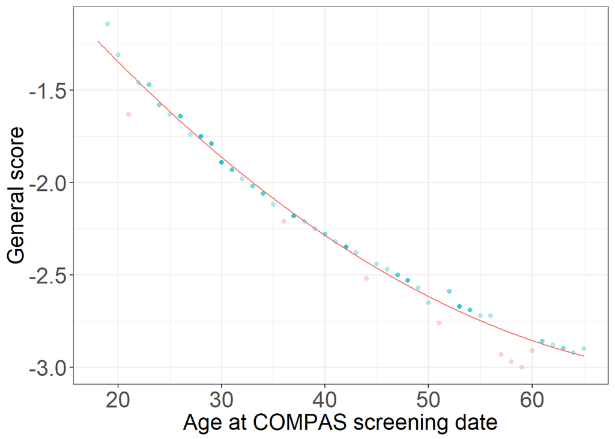

```r
ggplot()+
  geom_point(aes(x=p_current_age, raw_score, color = factor(filt7)),alpha=.3, data=lb_age) +
  geom_line(aes(x=xx, predict(mdl_age, newdata=data.frame(p_current_age=xx))),color="#F8766D") +
  theme_bw()+
  xlim(xmin,xmax)+
  xlab("Age at COMPAS screening date") +
  ylab("General score") +
  theme(text = element_text(size=18),
        axis.text=element_text(size=18),
        legend.position="none")
```

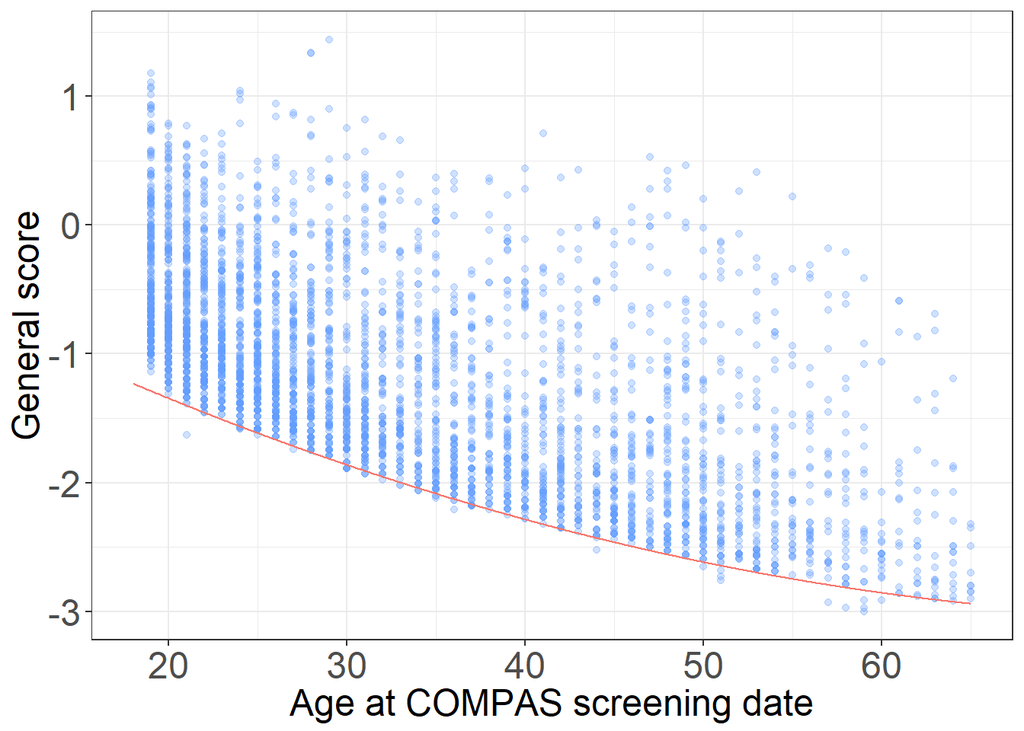

```r
ggplot()+
  geom_point(aes(x=p_current_age, raw_score), color="#619CFF",alpha=.3, data=features_age_poly) +
  geom_line(aes(x=xx, predict(mdl_age, newdata=data.frame(p_current_age=xx))),color="#F8766D") +
  theme_bw()+
  xlim(xmin,xmax)+
  xlab("Age at COMPAS screening date") +
  ylab("General score") +
  theme(text = element_text(size=18),
        axis.text=element_text(size=18),
        legend.position="none")
```

```r
features_age_spline = features %>%
    filter(filt1, filt5, filt6, filt7)


lb_filt = features_age_spline %>%
  group_by(p_current_age) %>%
    arrange(raw_score)%>%
    top_n(n=-1, wt = raw_score)

#filtered out points
lb_outliers = rbind(
                #reason not included in lb_filt was
                #age not above age poly
                setdiff(lb_age, lb_filt) %>%
                  filter(!filt7) %>% #below age poly
                  mutate(reason = "Below age polynomial")

                )

lb = lb_filt %>%
     select(p_current_age, p_age_first_offense, raw_score) %>%
     mutate(reason = "Used to construct linear splines") %>%
     rbind(lb_outliers)
```

Generating linear splines to fit the lower bound Plottng individuals on new bottom edge produced by fitting to lb_filt individuals.

```r
mdl_age_spline <- segmented(lm(raw_score ~ p_current_age, data = lb_filt),
                            seg.Z = ~p_current_age, psi = list(p_current_age = c(39,58)),
  control = seg.control(display = FALSE)
)
#Add Filter 8
features = features %>%
  mutate(
    age_spline = predict(mdl_age_spline, newdata=data.frame(p_current_age=p_current_age)),
    raw_score__age_spline = raw_score - age_spline,
    filt8 = raw_score >= age_spline - 0.05
  )
```

```r
intercept(mdl_age_spline)
```

```
## $p_current_age
##                Est.
## intercept1 -0.16169
## intercept2 -0.93965
## intercept3 -1.53780
```

```r
slope(mdl_age_spline)
```

```
## $p_current_age
##             Est.   St.Err. t value CI(95%).l CI(95%).u
## slope1 -0.057096 0.0012287 -46.468 -0.059535 -0.054656
## slope2 -0.033367 0.0008033 -41.538 -0.034962 -0.031772
## slope3 -0.021321 0.0010530 -20.248 -0.023412 -0.019231
```

```r
summary.segmented(mdl_age_spline)$psi
```

```
##                    Initial     Est.    St.Err
## psi1.p_current_age      39 32.78565 0.4652999
## psi2.p_current_age      58 49.65905 0.9888210
```

Note: the reason why the number of points below the age polynomial appear different between the two plots is that the first plot (displaying the points used to construct the linear spline) show only data points where criminal involvement = 0, whereas the second plot does not have this constraint. In other words, the first plot has filt6 applied whereas the second plot does not.

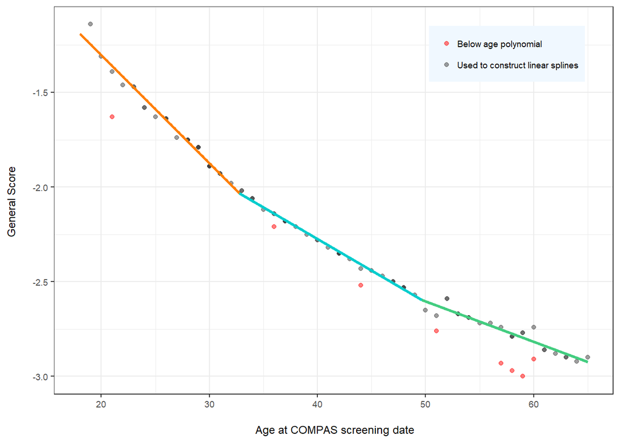

```r
break1 =  summary.segmented(mdl_age_spline)$psi[1,2]
break2 =  summary.segmented(mdl_age_spline)$psi[2,2]

xx1 = seq(xmin,break1, length.out=1000)
xx2 = seq(break1,break2, length.out=1000)
xx3 = seq(break2,xmax, length.out=1000)

age_spline_general =
  ggplot()+
  geom_point(aes(x=p_current_age, raw_score, color= factor(reason)),alpha=.5, data=lb ) +
  scale_color_manual(values=c("red", "grey25")) +
  geom_line(aes(x=xx1, y = predict(mdl_age_spline, newdata=data.frame(p_current_age=xx1))),
                color="darkorange1", size = 1) +
  geom_line(aes(x=xx2, y = predict(mdl_age_spline, newdata=data.frame(p_current_age=xx2))),
                color="cyan3", size = 1) +
  geom_line(aes(x=xx3, y = predict(mdl_age_spline, newdata=data.frame(p_current_age=xx3))),
                color="seagreen3", size = 1) +
  theme_bw()+
  xlim(xmin,xmax)+
  xlab("\n Age at COMPAS screening date") +
  ylab("General Score \n") +
  theme(text = element_text(size=9),
        axis.text=element_text(size=7),
        legend.position = c(.95,.95),
        legend.title = element_blank(),
        legend.justification = c("right", "top"),
        legend.key = element_rect(fill = "aliceblue"),
        legend.background = element_rect(fill="aliceblue",
                                  size=0.5, linetype="solid")
        )

age_spline_general
```

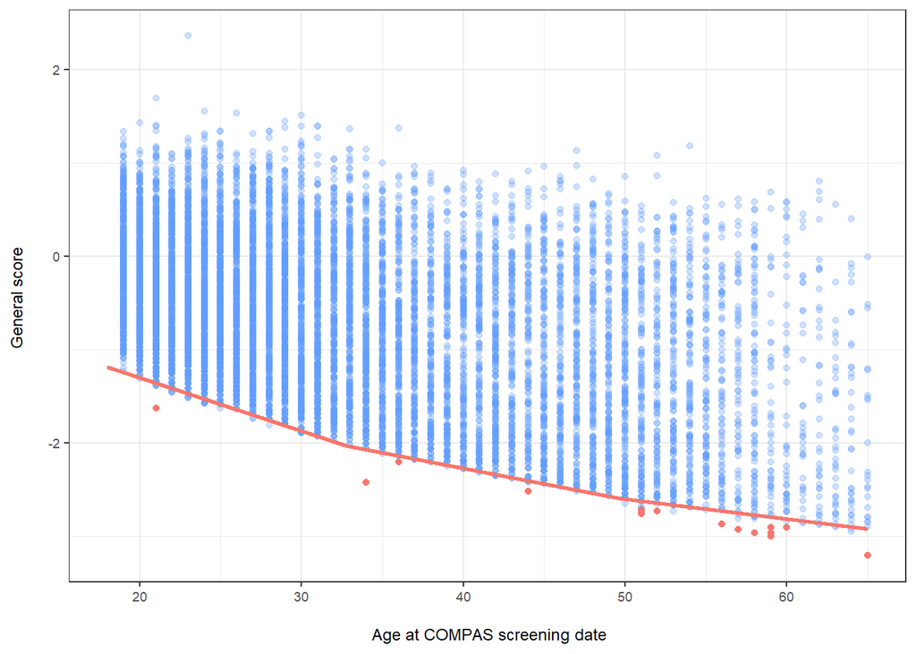

```r
# Age spline with all data (filters 1,5 still applied for data quality)
# Red points are below the age polynomial not age spline
age_spline_general_all =
  ggplot()+
  geom_point(aes(x=p_current_age, raw_score), color="#F8766D", data=features %>% filter(filt1,filt5,!filt7)) + # Age outliers
  geom_point(aes(x=p_current_age, raw_score), color="#619CFF", alpha=.3, data=features %>% filter(filt1,filt5,filt7)) + # Not age outliers
  geom_line(aes(x=xx1, y = predict(mdl_age_spline, newdata=data.frame(p_current_age=xx1))),
                color="#F8766D", size = 1) +
  geom_line(aes(x=xx2, y = predict(mdl_age_spline, newdata=data.frame(p_current_age=xx2))),
                color="#F8766D", size = 1) +
  geom_line(aes(x=xx3, y = predict(mdl_age_spline, newdata=data.frame(p_current_age=xx3))),
                color="#F8766D", size = 1) +
  theme_bw()+
  xlim(xmin,xmax)+
  xlab("\n Age at COMPAS screening date") +
  ylab("General score \n") +
  theme(text = element_text(size=9),
        axis.text=element_text(size=7),
        legend.position="top")

age_spline_general_all
```

```r
ggsave("Figures/predict_scores_general_charges/age_LB_general.pdf", plot = age_spline_general, width = 3.5, height = 2.5, units = "in")
ggsave("Figures/predict_scores_general_charges/age_LB_alldata_general.pdf", plot = age_spline_general_all, width = 3.5, height = 2.5, units = "in")
```

## Examine Criminal Involvement lower bound

### Look at COMPAS age remainder vs number of prior charges (important item in the crim inv subscale)

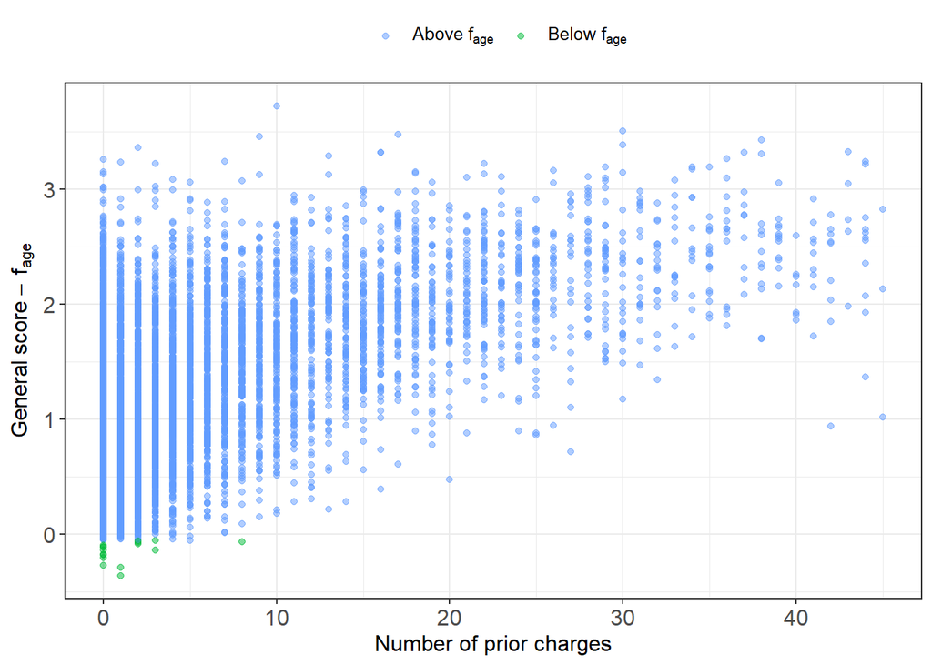

```r
prior_charges_LB_general = features %>%
          filter(filt1,filt3) %>%
          select(p_charge, raw_score__age_spline, filt8) %>%
          ggplot() +
          geom_point(aes(x=p_charge,y=raw_score__age_spline,color=filt8),alpha=.5) +
          xlim(c(0,45))+
          theme_bw()+
          xlab("Number of prior charges") +
          ylab(expression(General~score~-~f[age]))  +
          theme(text = element_text(size=12),
                axis.text=element_text(size=12),
                legend.position="top") +
          scale_color_manual(name=element_blank(),
                               breaks=c("TRUE", "FALSE"),
                               labels=c(expression(Above~f[age]),
                                        expression(Below~f[age])),
                               values=c("TRUE"="#619CFF","FALSE"="#00BA38"))

prior_charges_LB_general
```

```r
ggsave("Figures/predict_scores_general_charges/prior_charges_LB_general.pdf", plot=prior_charges_LB_general, width = 3.5, height = 2.5, units = "in")
```

### Look at COMPAS age remainder vs sum of items in Criminal Involvement subscale

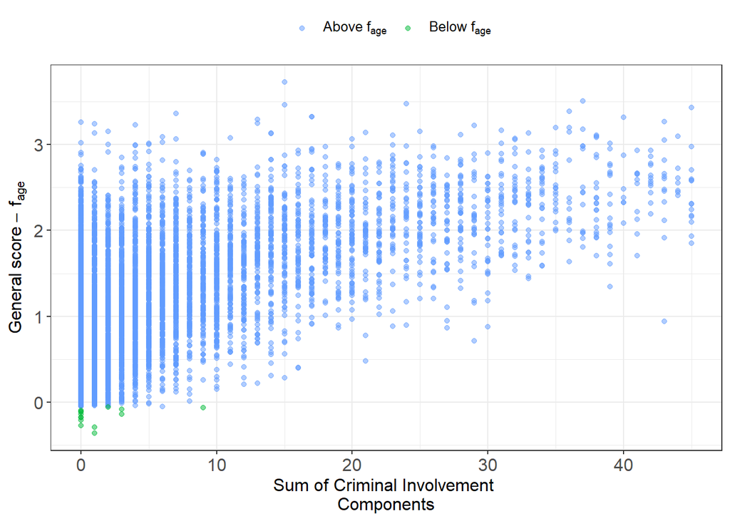

```r
features %>%
  filter(filt1,filt3, filt5) %>%
  select(crim_inv, raw_score__age_spline, filt8) %>%
  ggplot() +
    geom_point(aes(x=crim_inv,y=raw_score__age_spline,color=filt8),alpha=.5) +
    xlim(c(0,45))+
    theme_bw()+
    xlab("Sum of Criminal Involvement \nComponents") +
    ylab(expression(General~score~-~f[age]))  +
    theme(text = element_text(size=12),
          axis.text=element_text(size=12),
          legend.position="top") +
    scale_color_manual(name=element_blank(),
                         breaks=c("TRUE", "FALSE"),
                         labels=c(expression(Above~f[age]), expression(Below~f[age])),
                         values=c("TRUE"="#619CFF","FALSE"="#00BA38"))
```

```r
ggsave("Figures/predict_scores_general_charges/crim_inv_LB_general_charges.pdf",width = 3.5, height = 2.5, units = "in")
```

## Predictions of (raw - age polynomial) using several ML methods

There are a few groups of predictors we will use: * Group 0: without using age variables or race * Group 1: without using current age or race but with age at first arrest * Group 2: without using current age but with race and age at first arrest * Group 3: without using race but with current age and age at first arrest * Group 4: using age variables and race * Group 5: test

```r
#### Generic stuff (applies to all models)

## Filter rows
features_filt = features %>%
  filter(filt1, filt3)

## Set parameters (each combination will be run)
# xgboost
param <- list(objective = "reg:linear",
              eval_metric = "rmse",
              eta = c(.05,.1),
              gamma = c(.5, 1),
              max_depth = c(2,5),
              min_child_weight = c(5,10),
              subsample = c(1),
              colsample_bytree = c(1)
)

# svm
param_svm = list(
  type = 'eps-regression',
  cost = c(0.5,1,2),
  epsilon = c(0.5,1,1.5),
  gamma_scale = c(0.5,1,2)
)

res_rmse = data.frame(Group = 0:8, lm = NA, xgb = NA, rf = NA, svm = NA)
```

## Group 0 models: predicting (raw score - age spline) without using current age, age at first offense or race

```r
### Create group 0 training data

## Select features and round count features
train = features_filt %>%
  select(
    #p_current_age,
    # p_age_first_offense,
    p_charge,
    p_jail30,
    p_prison,
    p_probation,
    raw_score__age_spline)

## Format for xgboost
train_xgb = xgb.DMatrix(
  "data" = train %>% select(-raw_score__age_spline) %>% as.matrix(),
  "label" = train %>% select(raw_score__age_spline) %>% as.matrix()
)
```

### Model 1: Linear model

```r
mdl_lm = lm(raw_score__age_spline ~ ., data=train)
summary(mdl_lm)
```

```
##
## Call:
## lm(formula = raw_score__age_spline ~ ., data = train)
##
## Residuals:
##      Min       1Q   Median       3Q      Max
## -3.11745 -0.45665 -0.06349  0.39122  2.40544
##
## Coefficients:
##              Estimate Std. Error t value Pr(>|t|)
## (Intercept)  0.852024   0.007139 119.352   <2e-16 ***
## p_charge     0.027792   0.001029  27.001   <2e-16 ***
## p_jail30    -0.022982   0.040776  -0.564    0.573
## p_prison     0.202983   0.008570  23.686   <2e-16 ***
## p_probation  0.126451   0.007515  16.827   <2e-16 ***
## ---
## Signif. codes:  0 '***' 0.001 '**' 0.01 '*' 0.05 '.' 0.1 ' ' 1
##
## Residual standard error: 0.5804 on 9037 degrees of freedom
## Multiple R-squared:  0.3981, Adjusted R-squared:  0.3978
## F-statistic:  1494 on 4 and 9037 DF,  p-value: < 2.2e-16
```

```r
res_rmse[res_rmse$Group==0,]$lm = rmse(predict(mdl_lm, newdata=train), train$raw_score__age_spline) # ADJUST GROUP
```

### Model 2: xgboost

```r
set.seed(923)
mdl_xgb = fit_xgboost(train_xgb, param)
```

```
## Training on 16 sets of parameters.
##                  10
## objective        "reg:linear"
## eval_metric      "rmse"
## eta              "0.1"
## gamma            "0.5"
## max_depth        "2"
## min_child_weight "10"
## subsample        "1"
## colsample_bytree "1"
```

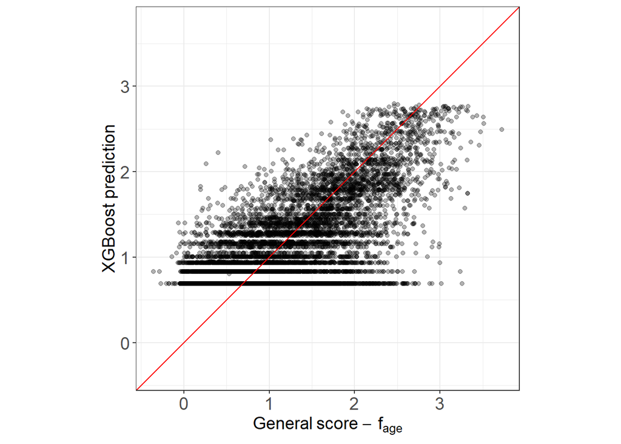

```r
### xgboost plot
pred = predict(mdl_xgb, newdata=train_xgb)
actual = train$raw_score__age_spline

res_rmse[res_rmse$Group==0,]$xgb = rmse(pred, actual) # ADJUST GROUP

axis_min = min(min(pred),min(actual))
axis_max = max(max(pred),max(actual))

data.frame(xgboost = pred, compas=actual) %>%
  ggplot() +
  geom_point(aes(x=compas,y=xgboost), alpha=.3) +
  geom_abline(slope=1, color="red")+
  xlim(c(axis_min,axis_max)) +
  ylim(c(axis_min,axis_max)) +
  coord_fixed() +
  theme_bw()+
  xlab(expression(General~score~-~f[age])) +
  ylab("XGBoost prediction")+
  theme(
        text = element_text(size=14),
        axis.text=element_text(size=14))
```

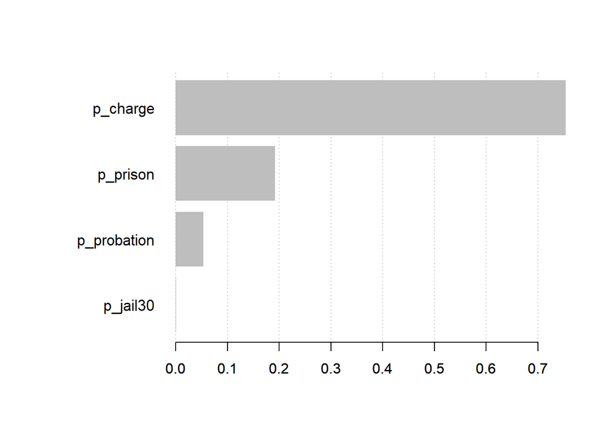

```r
### Variable importance
xgb.plot.importance(importance_matrix = xgb.importance(model = mdl_xgb))
```

### Model 3: random forest

```r
set.seed(784)

mdl_rf = randomForest(
  formula = raw_score__age_spline ~ .,
  data = train
)

res_rmse[res_rmse$Group==0,]$rf = rmse(mdl_rf$predicted, train$raw_score__age_spline) # ADJUST GROUP
```

### Model 4: SVM

```r
mdl_svm = fit_svm(raw_score__age_spline ~ ., train, param_svm)
```

```
## Training on 27 sets of parameters.
## [1] "Best parameters:"
##             12
## type        "eps-regression"
## cost        "2"
## epsilon     "0.5"
## gamma_scale "1"
## gamma       "0.2"
```

```r
res_rmse[res_rmse$Group==0,]$svm = rmse(mdl_svm$fitted, train$raw_score__age_spline) # ADJUST GROUP
```

### Cleanup

```r
rm(train, train_xgb, mdl_lm, mdl_xgb, mdl_rf, mdl_svm)
```

## Group 1 models: predicting (raw score - age spline) without using current age or race

```r
### Create group 1 training data

## Select features and round count features
train = features_filt %>%
  select(
    #p_current_age,
    p_age_first_offense,
    p_charge,
    p_jail30,
    p_prison,
    p_probation,
    raw_score__age_spline)

## Format for xgboost
train_xgb = xgb.DMatrix(
  "data" = train %>% select(-raw_score__age_spline) %>% as.matrix(),
  "label" = train %>% select(raw_score__age_spline) %>% as.matrix()
)
```

### Model 1: Linear model

```r
mdl_lm = lm(raw_score__age_spline ~ ., data=train)
summary(mdl_lm)
```

```
##
## Call:
## lm(formula = raw_score__age_spline ~ ., data = train)
##
## Residuals:
##      Min       1Q   Median       3Q      Max
## -2.70413 -0.45322 -0.06665  0.37492  2.52252
##
## Coefficients:
##                       Estimate Std. Error t value Pr(>|t|)
## (Intercept)          1.0504410  0.0177355  59.228   <2e-16 ***
## p_age_first_offense -0.0068081  0.0005579 -12.202   <2e-16 ***
## p_charge             0.0257267  0.0010349  24.858   <2e-16 ***
## p_jail30            -0.0075351  0.0404664  -0.186    0.852
## p_prison             0.2073028  0.0085077  24.367   <2e-16 ***
## p_probation          0.1201746  0.0074718  16.084   <2e-16 ***
## ---
## Signif. codes:  0 '***' 0.001 '**' 0.01 '*' 0.05 '.' 0.1 ' ' 1
##
## Residual standard error: 0.5757 on 9036 degrees of freedom
## Multiple R-squared:  0.4078, Adjusted R-squared:  0.4075
## F-statistic:  1245 on 5 and 9036 DF,  p-value: < 2.2e-16
```

```r
res_rmse[res_rmse$Group==1,]$lm = rmse(predict(mdl_lm, newdata=train), train$raw_score__age_spline) # ADJUST GROUP
```

### Model 2: xgboost

```r
set.seed(923)
mdl_xgb = fit_xgboost(train_xgb, param)
```

```
## Training on 16 sets of parameters.
##                  6
## objective        "reg:linear"
## eval_metric      "rmse"
## eta              "0.1"
## gamma            "0.5"
## max_depth        "5"
## min_child_weight "5"
## subsample        "1"
## colsample_bytree "1"
```

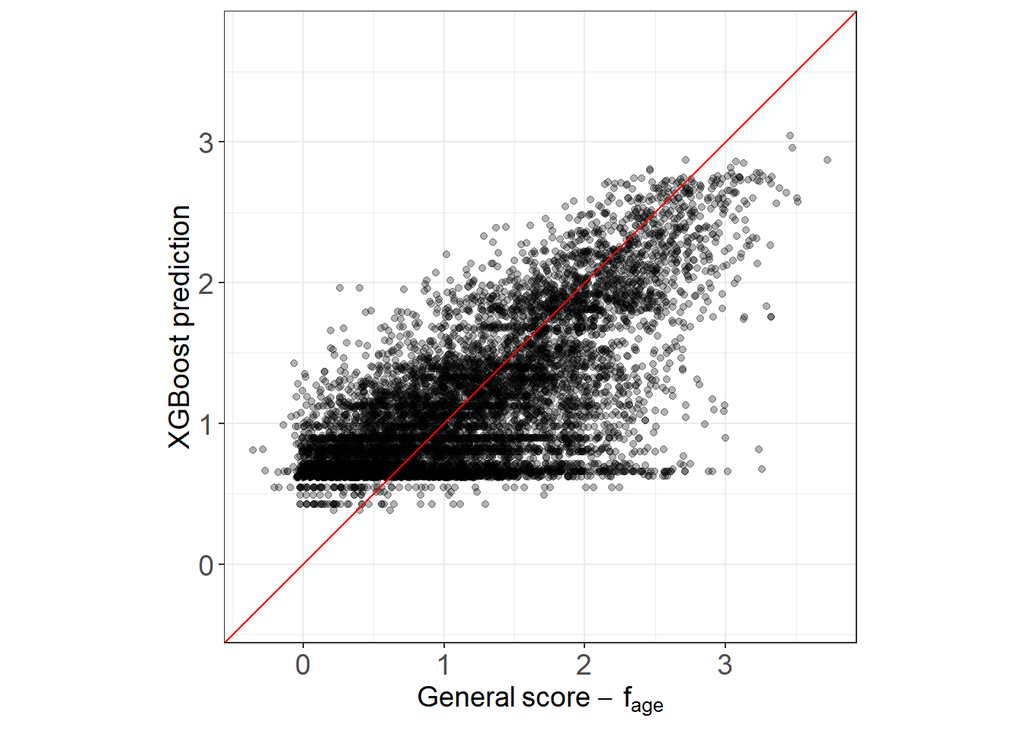

```r
### xgboost plot
pred = predict(mdl_xgb, newdata=train_xgb)
actual = train$raw_score__age_spline

res_rmse[res_rmse$Group==1,]$xgb = rmse(pred, actual) # ADJUST GROUP

axis_min = min(min(pred),min(actual))
axis_max = max(max(pred),max(actual))

data.frame(xgboost = pred, compas=actual) %>%
  ggplot() +
  geom_point(aes(x=compas,y=xgboost), alpha=.3) +
  geom_abline(slope=1, color="red")+
  xlim(c(axis_min,axis_max)) +
  ylim(c(axis_min,axis_max)) +
  coord_fixed() +
  theme_bw()+
  xlab(expression(General~score~-~f[age])) +
  ylab("XGBoost prediction")+
  theme(
        text = element_text(size=14),
        axis.text=element_text(size=14))
```

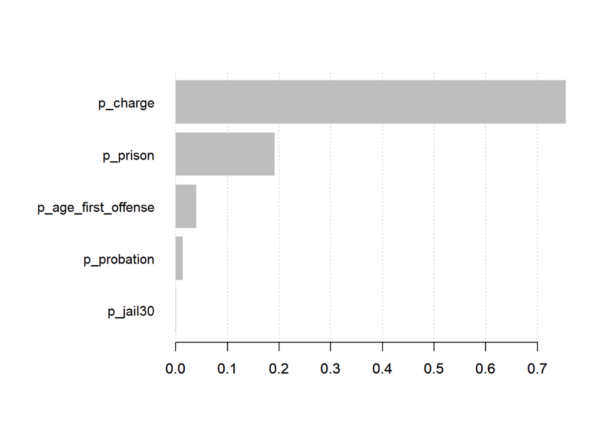

```r
### Variable importance
xgb.plot.importance(importance_matrix = xgb.importance(model = mdl_xgb))
```

### Model 3: random forest

```r
set.seed(784)

mdl_rf = randomForest(
  formula = raw_score__age_spline ~ .,
  data = train
)

res_rmse[res_rmse$Group==1,]$rf = rmse(mdl_rf$predicted, train$raw_score__age_spline) # ADJUST GROUP
```

### Model 4: SVM

```r
mdl_svm = fit_svm(raw_score__age_spline ~ ., train, param_svm)
```

```
## Training on 27 sets of parameters.
## [1] "Best parameters:"
##             19
## type        "eps-regression"
## cost        "0.5"
## epsilon     "0.5"
## gamma_scale "2"
## gamma       "0.3333333"
```

```r
res_rmse[res_rmse$Group==1,]$svm = rmse(mdl_svm$fitted, train$raw_score__age_spline) # ADJUST GROUP
```

### Cleanup

```r
rm(train, train_xgb, mdl_lm, mdl_xgb, mdl_rf, mdl_svm)
```

```r
### Create group 2 training data

## Select features and round count features
train = features_filt %>%
  select(
    #p_current_age,
    p_age_first_offense,
    p_charge,
    p_jail30,
    p_prison,
    p_probation,
    race_black,
    race_white,
    race_hispanic,
    race_asian,
    race_native, # race == "Other" is the baseline
    raw_score__age_spline)

## Format for xgboost
train_xgb = xgb.DMatrix(
  "data" = train %>% select(-raw_score__age_spline) %>% as.matrix(),
  "label" = train %>% select(raw_score__age_spline) %>% as.matrix()
)
```

### Model 1: Linear model

```r
mdl_lm = lm(raw_score__age_spline ~ ., data=train)
summary(mdl_lm)
```

```
##
## Call:
## lm(formula = raw_score__age_spline ~ ., data = train)
##
## Residuals:
##      Min       1Q   Median       3Q      Max
## -2.53060 -0.43756 -0.06332  0.36455  2.37212
##
## Coefficients:
##                       Estimate Std. Error t value Pr(>|t|)
## (Intercept)          0.7303562  0.0298037  24.506  < 2e-16 ***
## p_age_first_offense -0.0048406  0.0005678  -8.525  < 2e-16 ***
## p_charge             0.0248445  0.0010185  24.394  < 2e-16 ***
## p_jail30             0.0062435  0.0397795   0.157  0.87529
## p_prison             0.1974007  0.0083912  23.525  < 2e-16 ***
## p_probation          0.1170338  0.0073463  15.931  < 2e-16 ***
## race_black           0.3670895  0.0257223  14.271  < 2e-16 ***
## race_white           0.2429770  0.0259954   9.347  < 2e-16 ***
## race_hispanic        0.0877805  0.0311556   2.817  0.00485 **
## race_asian           0.0964432  0.0859460   1.122  0.26183
## race_native          0.2561583  0.1097042   2.335  0.01957 *
## ---
## Signif. codes:  0 '***' 0.001 '**' 0.01 '*' 0.05 '.' 0.1 ' ' 1
##
## Residual standard error: 0.5657 on 9031 degrees of freedom
## Multiple R-squared:  0.4286, Adjusted R-squared:  0.428
## F-statistic: 677.4 on 10 and 9031 DF,  p-value: < 2.2e-16
```

```r
res_rmse[res_rmse$Group==2,]$lm = rmse(predict(mdl_lm, newdata=train), train$raw_score__age_spline) # ADJUST GROUP
```

### Model 2: xgboost

```r
set.seed(480)
mdl_xgb = fit_xgboost(train_xgb, param)
```

```
## Training on 16 sets of parameters.
##                  14
## objective        "reg:linear"
## eval_metric      "rmse"
## eta              "0.1"
## gamma            "0.5"
## max_depth        "5"
## min_child_weight "10"
## subsample        "1"
## colsample_bytree "1"
```

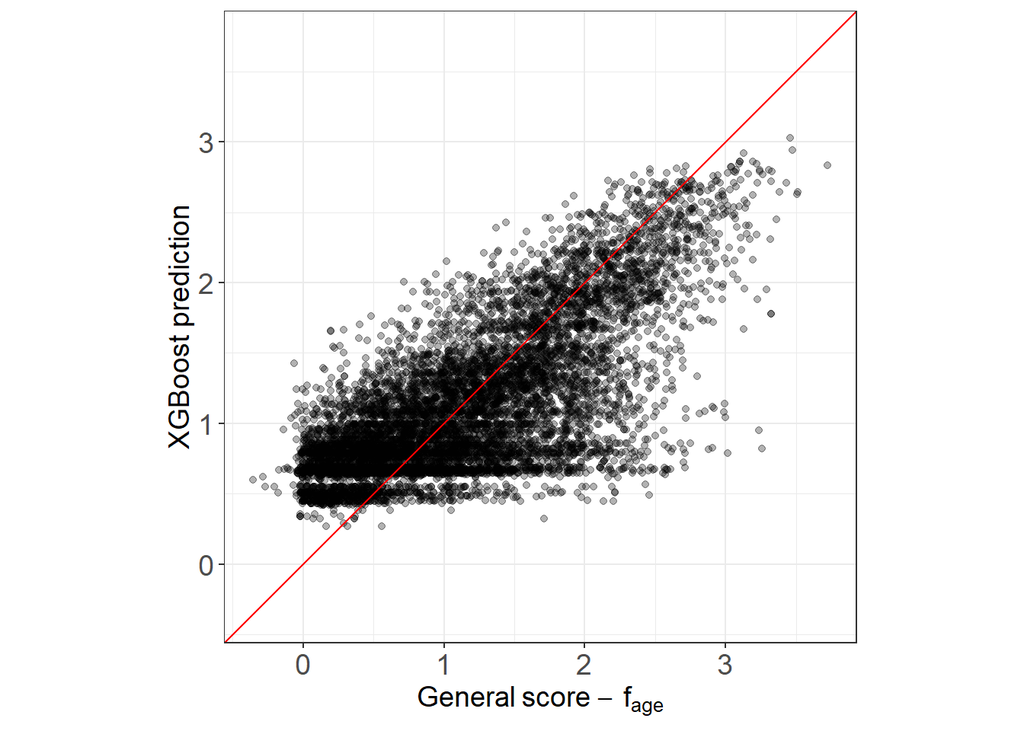

```r
### xgboost plot
pred = predict(mdl_xgb, newdata=train_xgb)
actual = train$raw_score__age_spline

res_rmse[res_rmse$Group==2,]$xgb = rmse(pred, actual) # ADJUST GROUP

axis_min = min(min(pred),min(actual))
axis_max = max(max(pred),max(actual))

data.frame(xgboost = pred, compas=actual) %>%
  ggplot() +
  geom_point(aes(x=compas,y=xgboost), alpha=.3) +
  geom_abline(slope=1, color="red")+
  xlim(c(axis_min,axis_max)) +
  ylim(c(axis_min,axis_max)) +
  coord_fixed() +
  theme_bw()+
  xlab(expression(General~score~-~f[age])) +
  ylab("XGBoost prediction")+
  theme(
        text = element_text(size=14),
        axis.text=element_text(size=14))
```

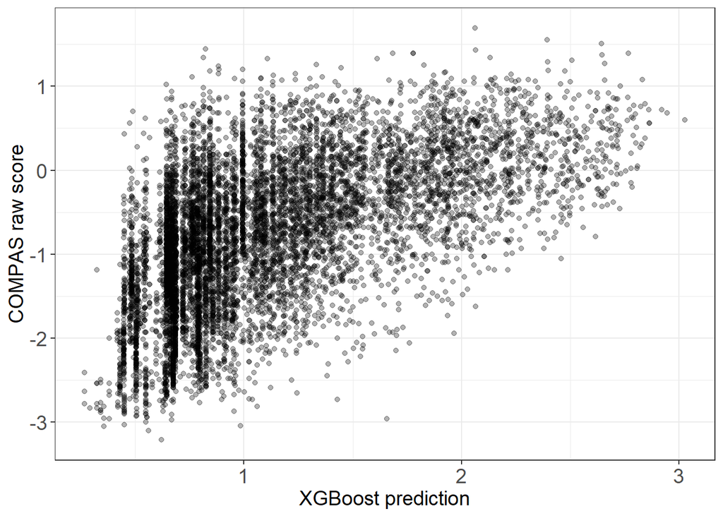

```r
data.frame(xgboost = pred, compas=features_filt$raw_score) %>%
  ggplot() +
  geom_point(aes(x=xgboost,y=compas), alpha=.3) +
  theme_bw()+
  xlab("XGBoost prediction") +
  ylab("COMPAS raw score")+
  theme(
        text = element_text(size=14),
        axis.text=element_text(size=14))
```

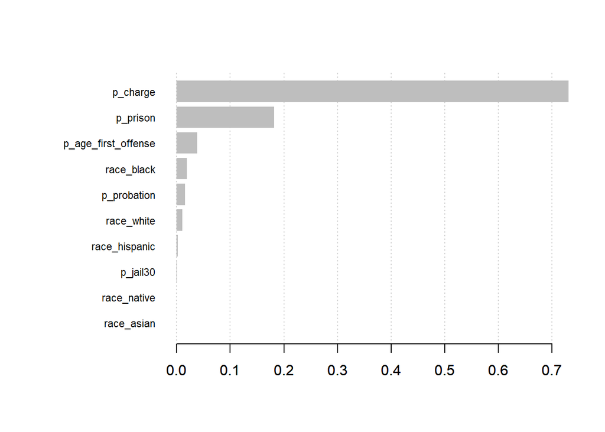

```r
### Variable importance
xgb.plot.importance(importance_matrix = xgb.importance(model = mdl_xgb))
```

### Model 3: random forest

```r
set.seed(6778)

mdl_rf = randomForest(
  formula = raw_score__age_spline ~ .,
  data = train
)

res_rmse[res_rmse$Group==2,]$rf = rmse(mdl_rf$predicted, train$raw_score__age_spline) # ADJUST GROUP
```

### Model 4: SVM

```r
mdl_svm = fit_svm(raw_score__age_spline ~ ., train, param_svm)
```

```
## Training on 27 sets of parameters.
## [1] "Best parameters:"
##             11
## type        "eps-regression"
## cost        "1"
## epsilon     "0.5"
## gamma_scale "1"
## gamma       "0.09090909"
```

```r
res_rmse[res_rmse$Group==2,]$svm = rmse(mdl_svm$fitted, train$raw_score__age_spline) # ADJUST GROUP
```

### Cleanup

```r
rm(train, train_xgb, mdl_lm, mdl_xgb, mdl_rf)
```

## Group 3 models: predicting (raw score - age spline) without using race but with age variables

```r
### Create group 3 training data

## Select features and round count features
train = features_filt %>%
  select(
    p_current_age,
    p_age_first_offense,
    p_charge,
    p_jail30,
    p_prison,
    p_probation,
    raw_score__age_spline)

## Format for xgboost
train_xgb = xgb.DMatrix(
  "data" = train %>% select(-raw_score__age_spline) %>% as.matrix(),
  "label" = train %>% select(raw_score__age_spline) %>% as.matrix()
)
```

### Model 1: Linear model

```r
mdl_lm = lm(raw_score__age_spline ~ ., data=train)
summary(mdl_lm)
```

```
##
## Call:
## lm(formula = raw_score__age_spline ~ ., data = train)
##
## Residuals:
##      Min       1Q   Median       3Q      Max
## -2.29239 -0.44879 -0.07209  0.36872  2.53397
##
## Coefficients:
##                      Estimate Std. Error t value Pr(>|t|)
## (Intercept)          1.009433   0.018161  55.581   <2e-16 ***
## p_current_age        0.011522   0.001205   9.560   <2e-16 ***
## p_age_first_offense -0.017721   0.001269 -13.960   <2e-16 ***
## p_charge             0.022990   0.001069  21.509   <2e-16 ***
## p_jail30             0.020813   0.040375   0.515    0.606
## p_prison             0.183286   0.008830  20.756   <2e-16 ***
## p_probation          0.098878   0.007761  12.740   <2e-16 ***
## ---
## Signif. codes:  0 '***' 0.001 '**' 0.01 '*' 0.05 '.' 0.1 ' ' 1
##
## Residual standard error: 0.5729 on 9035 degrees of freedom
## Multiple R-squared:  0.4138, Adjusted R-squared:  0.4134
## F-statistic:  1063 on 6 and 9035 DF,  p-value: < 2.2e-16
```

```r
res_rmse[res_rmse$Group==3,]$lm = rmse(predict(mdl_lm, newdata=train), train$raw_score__age_spline) # ADJUST GROUP
```

### Model 2: xgboost

```r
set.seed(999)
mdl_xgb = fit_xgboost(train_xgb, param)
```

```
## Training on 16 sets of parameters.
##                  15
## objective        "reg:linear"
## eval_metric      "rmse"
## eta              "0.05"
## gamma            "1"
## max_depth        "5"
## min_child_weight "10"
## subsample        "1"
## colsample_bytree "1"
```

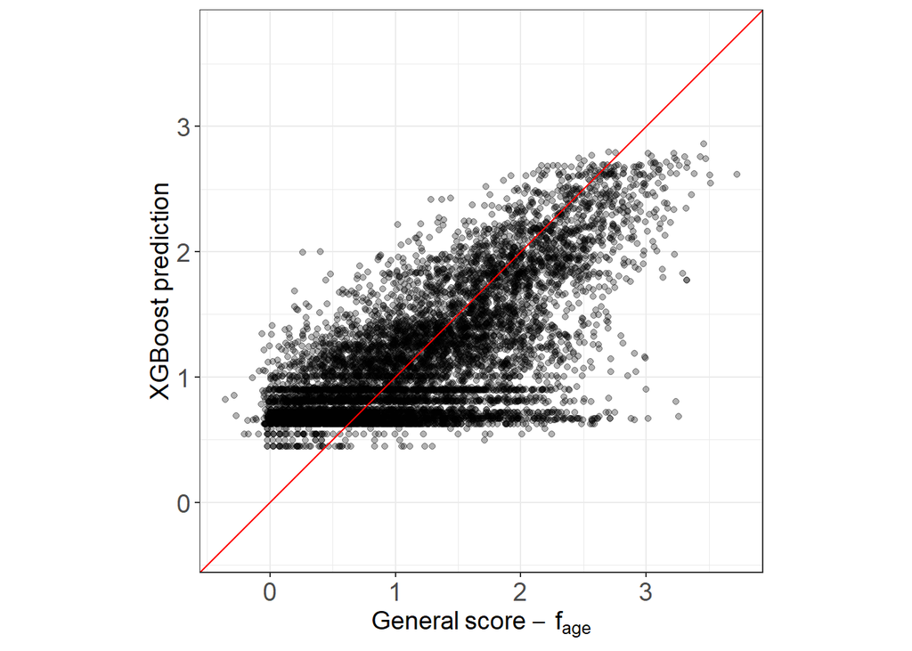

```r
### xgboost plot
pred = predict(mdl_xgb, newdata=train_xgb)
actual = train$raw_score__age_spline

res_rmse[res_rmse$Group==3,]$xgb = rmse(pred, actual) # ADJUST GROUP

axis_min = min(min(pred),min(actual))
axis_max = max(max(pred),max(actual))

data.frame(xgboost = pred, compas=actual) %>%
  ggplot() +
  geom_point(aes(x=compas,y=xgboost), alpha=.3) +
  geom_abline(slope=1, color="red")+
  xlim(c(axis_min,axis_max)) +
  ylim(c(axis_min,axis_max)) +
  coord_fixed() +
  theme_bw()+
  xlab(expression(General~score~-~f[age])) +
  ylab("XGBoost prediction")+
  theme(
        text = element_text(size=14),
        axis.text=element_text(size=14))
```

```r
ggsave("Figures/predict_scores_general_charges/raw-fage_xgboost_gp3_general.pdf",width = 3, height = 3, units = "in")
```

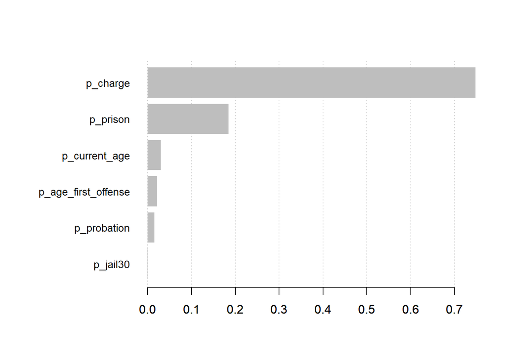

```r
### Variable importance
xgb.plot.importance(importance_matrix = xgb.importance(model = mdl_xgb))
```

### Model 3: random forest

```r
set.seed(5)

mdl_rf = randomForest(
  formula = raw_score__age_spline ~ .,
  data = train
)

res_rmse[res_rmse$Group==3,]$rf = rmse(mdl_rf$predicted, train$raw_score__age_spline) # ADJUST GROUP
```

### Model 4: SVM

```r
mdl_svm = fit_svm(raw_score__age_spline ~ ., train, param_svm)
```

```
## Training on 27 sets of parameters.
## [1] "Best parameters:"
##             19
## type        "eps-regression"
## cost        "0.5"
## epsilon     "0.5"
## gamma_scale "2"
## gamma       "0.2857143"
```

```r
res_rmse[res_rmse$Group==3,]$svm = rmse(mdl_svm$fitted, train$raw_score__age_spline) # ADJUST GROUP
```

### Cleanup

```r
rm(train, train_xgb, mdl_lm, mdl_xgb, mdl_rf)
```

## Group 4 models: predicting (raw score - age spline) using age variables and race

```r
### Create group 2 training data

## Select features and round count features
train = features_filt %>%
  select(
    p_current_age,
    p_age_first_offense,
    p_charge,
    p_jail30,
    p_prison,
    p_probation,
    race_black,
    race_white,
    race_hispanic,
    race_asian,
    race_native, # race == "Other" is the baseline
    raw_score__age_spline)

## Format for xgboost
train_xgb = xgb.DMatrix(
  "data" = train %>% select(-raw_score__age_spline) %>% as.matrix(),
  "label" = train %>% select(raw_score__age_spline) %>% as.matrix()
)
```

### Model 1: Linear model

```r
mdl_lm = lm(raw_score__age_spline ~ ., data=train)
summary(mdl_lm)
```

```
##
## Call:
## lm(formula = raw_score__age_spline ~ ., data = train)
##
## Residuals:
##      Min       1Q   Median       3Q      Max
## -2.11664 -0.43169 -0.06331  0.36310  2.38047
##
## Coefficients:
##                      Estimate Std. Error t value Pr(>|t|)
## (Intercept)          0.689442   0.029956  23.016  < 2e-16 ***
## p_current_age        0.011441   0.001187   9.638  < 2e-16 ***
## p_age_first_offense -0.015628   0.001254 -12.465  < 2e-16 ***
## p_charge             0.022123   0.001052  21.030  < 2e-16 ***
## p_jail30             0.034763   0.039689   0.876  0.38112
## p_prison             0.173340   0.008714  19.892  < 2e-16 ***
## p_probation          0.095978   0.007629  12.581  < 2e-16 ***
## race_black           0.367771   0.025593  14.370  < 2e-16 ***
## race_white           0.237060   0.025871   9.163  < 2e-16 ***
## race_hispanic        0.094510   0.031006   3.048  0.00231 **
## race_asian           0.105539   0.085517   1.234  0.21719
## race_native          0.244430   0.109157   2.239  0.02516 *
## ---
## Signif. codes:  0 '***' 0.001 '**' 0.01 '*' 0.05 '.' 0.1 ' ' 1
##
## Residual standard error: 0.5628 on 9030 degrees of freedom
## Multiple R-squared:  0.4344, Adjusted R-squared:  0.4337
## F-statistic: 630.5 on 11 and 9030 DF,  p-value: < 2.2e-16
```

```r
res_rmse[res_rmse$Group==4,]$lm = rmse(predict(mdl_lm, newdata=train), train$raw_score__age_spline) # ADJUST GROUP
```

### Model 2: xgboost

```r
set.seed(23)
mdl_xgb = fit_xgboost(train_xgb, param)
```

```
## Training on 16 sets of parameters.
##                  5
## objective        "reg:linear"
## eval_metric      "rmse"
## eta              "0.05"
## gamma            "0.5"
## max_depth        "5"
## min_child_weight "5"
## subsample        "1"
## colsample_bytree "1"
```

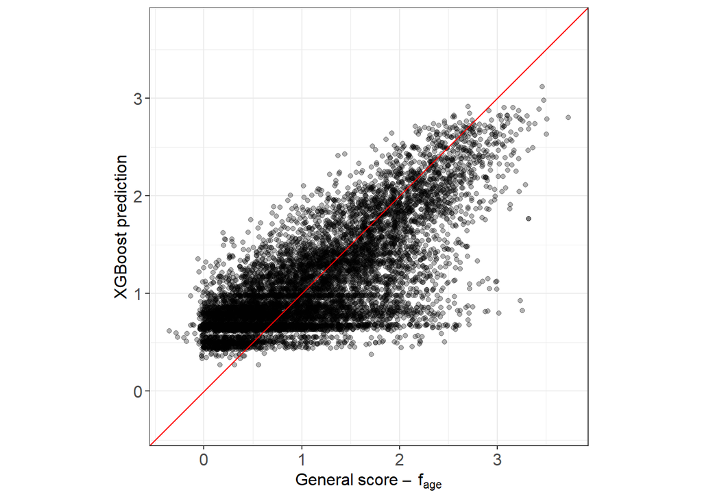

```r
### xgboost plot
pred = predict(mdl_xgb, newdata=train_xgb)
actual = train$raw_score__age_spline

res_rmse[res_rmse$Group==4,]$xgb = rmse(pred, actual) # ADJUST GROUP

axis_min = min(min(pred),min(actual))
axis_max = max(max(pred),max(actual))

data.frame(xgboost = pred, compas=actual) %>%
  ggplot() +
  geom_point(aes(x=compas,y=xgboost), alpha=.3) +
  geom_abline(slope=1, color="red")+
  xlim(c(axis_min,axis_max)) +
  ylim(c(axis_min,axis_max)) +
  coord_fixed() +
  theme_bw()+
  xlab(expression(General~score~-~f[age])) +
  ylab("XGBoost prediction")+
  theme(
        text = element_text(size=12),
        axis.text=element_text(size=12))
```

```r
ggsave("Figures/predict_scores_general_charges/raw-fage_xgboost_gp4_general.pdf",width = 3, height = 3, units = "in")
```

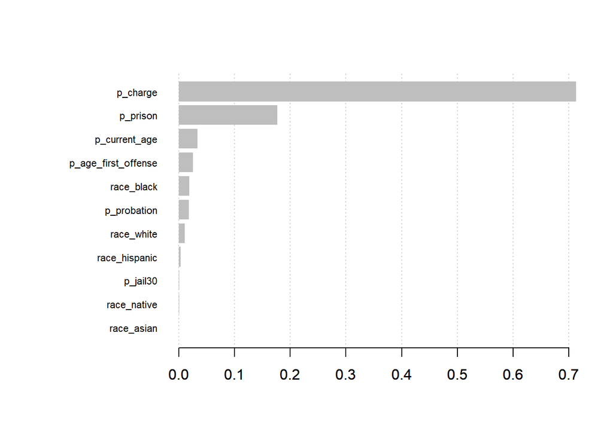

```r
### Variable importance
xgb.plot.importance(importance_matrix = xgb.importance(model = mdl_xgb))
```

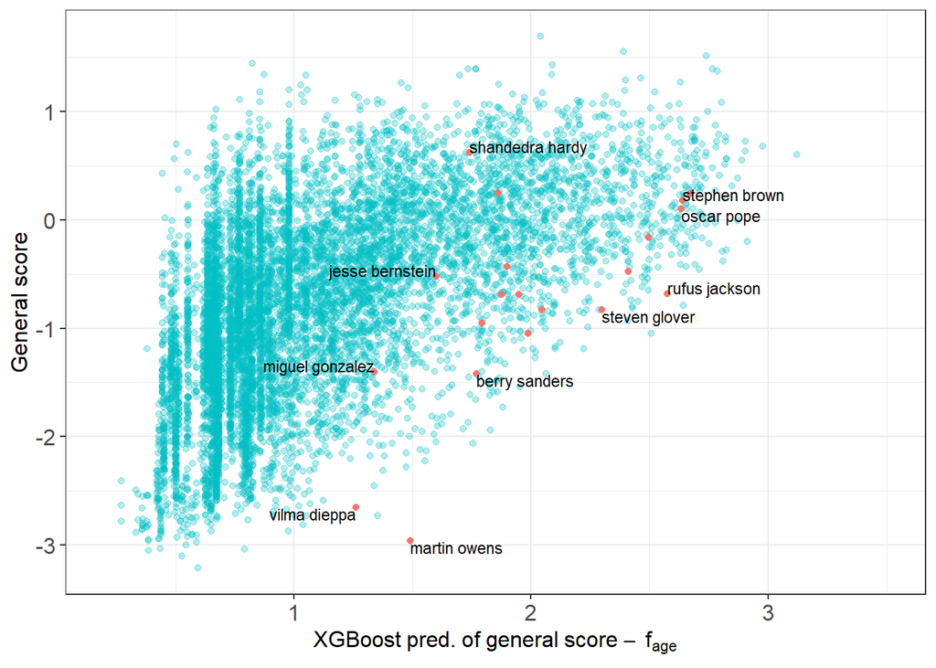

```r
highlight = data.frame(
  person_id= c(799, 1284, 1394, 1497, 1515, 1638, 3145, 3291, 5722, 6337, 6886, 7997, 8200, 8375, 8491, 10553, 10774, 11231, 11312, 11414),
  screening_date = ymd(c("2014-06-15","2014-05-14","2014-11-28","2013-07-29","2013-10-23","2013-10-04","2014-12-14","2013-01-17","2013-10-24","2014-02-04","2013-07-12","2014-04-26","2014-05-05","2013-03-19","2014-01-18","2014-09-20","2013-04-09","2014-02-23","2014-05-02","2014-11-26")),
  highlight = TRUE
)

df_plot = features_filt %>%
  bind_cols(xgboost = predict(mdl_xgb, newdata=train_xgb)) %>%
  left_join(highlight, by = c("person_id","screening_date")) %>%
  mutate(highlight = if_else(is.na(highlight), FALSE, TRUE)) %>%
  mutate(highlight = factor(if_else(highlight==TRUE,"In Table 5", "Not in Table 5"), levels=c("In Table 5", "Not in Table 5")))

person_id_text_topright = c(8375, 11231, 1515)
#person_id_text_topright = highlight$person_id
person_id_text_topleft = c(1394, 1497)
person_id_text_botright = c(11312, 6886, 8491, 10774)
person_id_text_botleft = c(799)

ggplot() +
  geom_point(aes(x=xgboost,y=raw_score, color=highlight),  alpha = .3, data = filter(df_plot, highlight=="Not in Table 5")) +
  geom_point(aes(x=xgboost,y=raw_score, color=highlight),  data = filter(df_plot, highlight=="In Table 5")) +
  theme_bw()+
  geom_text(aes(x=xgboost,y=raw_score,label=name),size=3,nudge_x=0, nudge_y=0, hjust="left",vjust="bottom", data=filter(df_plot, person_id %in% person_id_text_topright & highlight=="In Table 5")) +
  geom_text(aes(x=xgboost,y=raw_score,label=name),size=3,nudge_x=0, nudge_y=0, hjust="right",vjust="bottom", data=filter(df_plot, person_id %in% person_id_text_topleft & highlight=="In Table 5")) +
  geom_text(aes(x=xgboost,y=raw_score,label=name),size=3,nudge_x=0, nudge_y=0, hjust="left",vjust="top", data=filter(df_plot, person_id %in% person_id_text_botright & highlight=="In Table 5")) +
  geom_text(aes(x=xgboost,y=raw_score,label=name),size=3,nudge_x=0, nudge_y=0, hjust="right",vjust="top", data=filter(df_plot, person_id %in% person_id_text_botleft & highlight=="In Table 5")) +
  xlab(expression(XGBoost~pred.~of~general~score~-~f[age])) +
  ylab("General score")+
  theme(
    text = element_text(size=12),
    axis.text=element_text(size=12),
    #legend.position = "top",
    legend.position="none") +
  scale_color_discrete(name = element_blank()) +
  xlim(0.2,3.5)
```

```r
ggsave("Figures/predict_scores_general_charges/xgboost_rawScore_annotate_general.pdf",width = 4, height = 4, units = "in")
```

### Model 3: random forest

```r
set.seed(3720)

mdl_rf = randomForest(
  formula = raw_score__age_spline ~ .,
  data = train
)

res_rmse[res_rmse$Group==4,]$rf = rmse(mdl_rf$predicted, train$raw_score__age_spline) # ADJUST GROUP
```

### Model 4: SVM

```r
mdl_svm = fit_svm(raw_score__age_spline ~ ., train, param_svm)
```

```
## Training on 27 sets of parameters.
## [1] "Best parameters:"
##             12
## type        "eps-regression"
## cost        "2"
## epsilon     "0.5"
## gamma_scale "1"
## gamma       "0.08333333"
```

```r
res_rmse[res_rmse$Group==4,]$svm = rmse(mdl_svm$fitted, train$raw_score__age_spline) # ADJUST GROUP
```

### Cleanup

```r
rm(train, train_xgb, mdl_lm, mdl_xgb, mdl_rf)
```

## Group 5 models: test

```r
### Create group 5 training data

## Select features and round count features
train = features_filt %>%
  select(
    p_current_age,
    p_age_first_offense,
    p_charge,
    p_jail30,
    p_prison30,
    p_prison,
    p_probation,
    race_black,
    race_white,
    race_hispanic,
    race_asian,
    race_native, # race == "Other" is the baseline
    raw_score__age_spline)

## Format for xgboost
train_xgb = xgb.DMatrix(
  "data" = train %>% select(-raw_score__age_spline) %>% as.matrix(),
  "label" = train %>% select(raw_score__age_spline) %>% as.matrix()
)
```

### Model 1: Linear model

```r
mdl_lm = lm(raw_score__age_spline ~ ., data=train)
summary(mdl_lm)
```

```
##
## Call:
## lm(formula = raw_score__age_spline ~ ., data = train)
##
## Residuals:
##      Min       1Q   Median       3Q      Max
## -2.11664 -0.43169 -0.06331  0.36310  2.38047
##
## Coefficients: (1 not defined because of singularities)
##                      Estimate Std. Error t value Pr(>|t|)
## (Intercept)          0.689442   0.029956  23.016  < 2e-16 ***
## p_current_age        0.011441   0.001187   9.638  < 2e-16 ***
## p_age_first_offense -0.015628   0.001254 -12.465  < 2e-16 ***
## p_charge             0.022123   0.001052  21.030  < 2e-16 ***
## p_jail30             0.034763   0.039689   0.876  0.38112
## p_prison30                 NA         NA      NA       NA
## p_prison             0.173340   0.008714  19.892  < 2e-16 ***
## p_probation          0.095978   0.007629  12.581  < 2e-16 ***
## race_black           0.367771   0.025593  14.370  < 2e-16 ***
## race_white           0.237060   0.025871   9.163  < 2e-16 ***
## race_hispanic        0.094510   0.031006   3.048  0.00231 **
## race_asian           0.105539   0.085517   1.234  0.21719
## race_native          0.244430   0.109157   2.239  0.02516 *
## ---
## Signif. codes:  0 '***' 0.001 '**' 0.01 '*' 0.05 '.' 0.1 ' ' 1
##
## Residual standard error: 0.5628 on 9030 degrees of freedom
## Multiple R-squared:  0.4344, Adjusted R-squared:  0.4337
## F-statistic: 630.5 on 11 and 9030 DF,  p-value: < 2.2e-16
```

```r
res_rmse[res_rmse$Group==5,]$lm = rmse(predict(mdl_lm, newdata=train), train$raw_score__age_spline) # ADJUST GROUP
```

### Model 2: xgboost

```r
set.seed(480)
mdl_xgb = fit_xgboost(train_xgb, param)
```

```
## Training on 16 sets of parameters.
##                  14
## objective        "reg:linear"
## eval_metric      "rmse"
## eta              "0.1"
## gamma            "0.5"
## max_depth        "5"
## min_child_weight "10"
## subsample        "1"
## colsample_bytree "1"
```

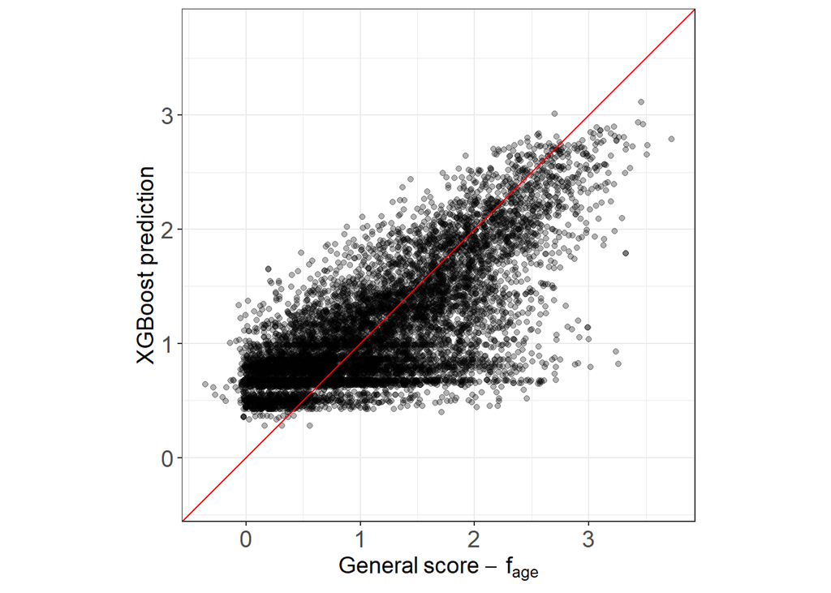

```r
### xgboost plot
pred = predict(mdl_xgb, newdata=train_xgb)
actual = train$raw_score__age_spline

res_rmse[res_rmse$Group==5,]$xgb = rmse(pred, actual) # ADJUST GROUP

axis_min = min(min(pred),min(actual))
axis_max = max(max(pred),max(actual))

data.frame(xgboost = pred, compas=actual) %>%
  ggplot() +
  geom_point(aes(x=compas,y=xgboost), alpha=.3) +
  geom_abline(slope=1, color="red")+
  xlim(c(axis_min,axis_max)) +
  ylim(c(axis_min,axis_max)) +
  coord_fixed() +
  theme_bw()+
  xlab(expression(General~score~-~f[age])) +
  ylab("XGBoost prediction")+
  theme(
        text = element_text(size=14),
        axis.text=element_text(size=14))
```

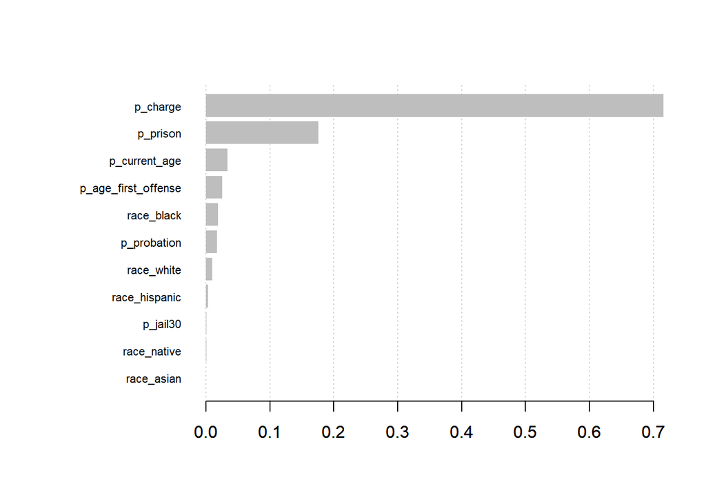

```r
### Variable importance
xgb.plot.importance(importance_matrix = xgb.importance(model = mdl_xgb))
```

### Model 3: random forest

```r
set.seed(1123)

mdl_rf = randomForest(
  formula = raw_score__age_spline ~ .,
  data = train
)

res_rmse[res_rmse$Group==5,]$rf = rmse(mdl_rf$predicted, train$raw_score__age_spline) # ADJUST GROUP
```

### Model 4: SVM

```r
mdl_svm = fit_svm(raw_score__age_spline ~ ., train, param_svm)
```

```
## Training on 27 sets of parameters.
## [1] "Best parameters:"
##             20
## type        "eps-regression"
## cost        "1"
## epsilon     "0.5"
## gamma_scale "2"
## gamma       "0.1538462"
```

```r
res_rmse[res_rmse$Group==5,]$svm = rmse(mdl_svm$fitted, train$raw_score__age_spline) # ADJUST GROUP
```

### Cleanup

```r
rm(train, train_xgb, mdl_lm, mdl_xgb, mdl_rf)
```

## Comparison

```r
knitr::kable(res_rmse)
```

| Group | lm | xgb | rf | svm |
| --- | --- | --- | --- | --- |
| 0 | 0.5802547 | 0.5357662 | 0.5618949 | 0.5356210 |
| 1 | 0.5755323 | 0.5227144 | 0.5550624 | 0.5296244 |
| 2 | 0.5653589 | 0.5128933 | 0.5271992 | 0.5234295 |
| 3 | 0.5726434 | 0.5201723 | 0.5326400 | 0.5244208 |
| 4 | 0.5624732 | 0.5058625 | 0.5255005 | 0.5179857 |
| 5 | 0.5624732 | 0.5063020 | 0.5249877 | 0.5155588 |
| 6 | NA | NA | NA | NA |
| 7 | NA | NA | NA | NA |
| 8 | NA | NA | NA | NA |

# Predictions using xgboost only

## Predicting the raw score

```r
### Create group 3 training data

## Select features and round count features
train = features_filt %>%
  select(
    p_current_age,
    p_age_first_offense,
    p_charge,
    p_jail30,
    p_prison,
    p_probation,
    raw_score)

## Format for xgboost
train_xgb = xgb.DMatrix(
  "data" = train %>% select(-raw_score) %>% as.matrix(),
  "label" = train %>% select(raw_score) %>% as.matrix()
)
```

```r
set.seed(540)
mdl_xgb = fit_xgboost(train_xgb, param)
```

```
## Training on 16 sets of parameters.
##                  5
## objective        "reg:linear"
## eval_metric      "rmse"
## eta              "0.05"
## gamma            "0.5"
## max_depth        "5"
## min_child_weight "5"
## subsample        "1"
## colsample_bytree "1"
```

```r
### xgboost plot
pred = predict(mdl_xgb, newdata=train_xgb)
actual = train$raw_score

print(paste("RMSE:",round(rmse(pred, actual),4)))
```

```
## [1] "RMSE: 0.511"
```

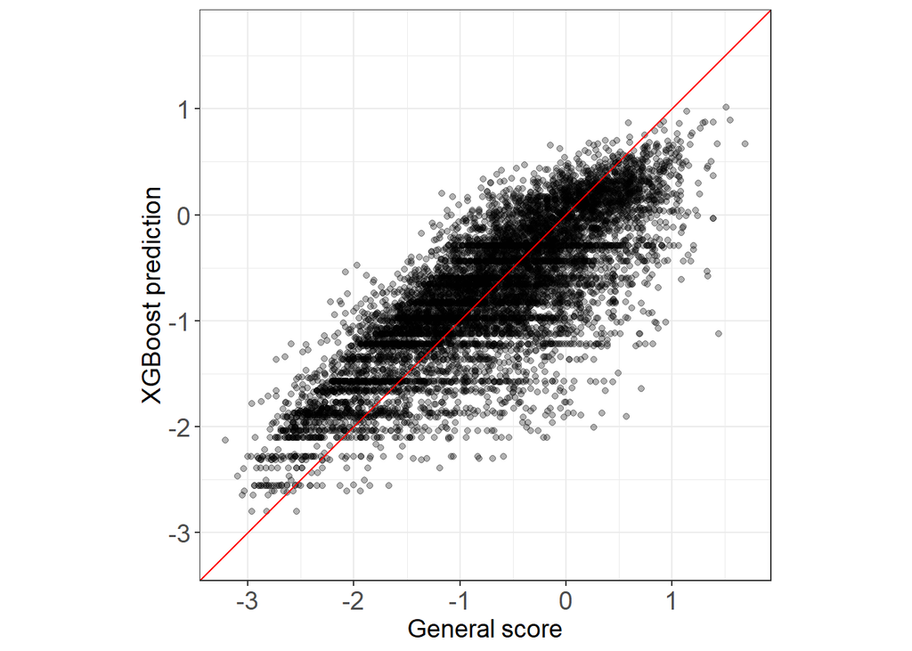

```r
axis_min = min(min(pred),min(actual))
axis_max = max(max(pred),max(actual))

data.frame(xgboost = pred, compas=actual) %>%
  ggplot() +
  geom_point(aes(x=compas,y=xgboost), alpha=.3) +
  geom_abline(slope=1, color="red")+
  xlim(c(axis_min,axis_max)) +
  ylim(c(axis_min,axis_max)) +
  coord_fixed() +
  theme_bw()+
  xlab("General score") +
  ylab("XGBoost prediction")+
  #annotate("text", x = -3.5, y = 0.5, label = paste("RMSE:",round(rmse(pred, actual),4)))+
  theme(
    text = element_text(size=14),
    axis.text=element_text(size=14))
```

```r
ggsave("Figures/predict_scores_general_charges/raw_xgboost_gp3_general.pdf",width = 3, height = 3, units = "in")
```

## Replicating ProPublica logistic regression

```r
propub = features_filt %>%
  filter(filt4) %>% # Only people with valid recidivism values
  mutate(age_low = if_else(p_current_age < 25,1,0),
         age_high = if_else(p_current_age > 45,1,0),
         female = if_else(sex=="Female",1,0),
         n_priors = p_felony_count_person + p_misdem_count_person,
         compas_high = if_else(`Risk of Recidivism_decile_score` >= 5, 1, 0), # Medium and High risk scores get +1 label
         race = relevel(factor(race), ref="Caucasian")) # Base level is Caucasian, as in ProPublica analysis

print(paste("Number of observations for logistic regression:",nrow(propub)))
```

```
## [1] "Number of observations for logistic regression: 5759"
```

```r
mdl_glm = glm(compas_high ~
                female +
                age_high +
                age_low +
                as.factor(race) +
                p_charge +
                is_misdem +
                recid,
                family=binomial(link='logit'), data=propub)

summary(mdl_glm)
```

```
##
## Call:
## glm(formula = compas_high ~ female + age_high + age_low + as.factor(race) +
##     p_charge + is_misdem + recid, family = binomial(link = "logit"),
##     data = propub)
##
## Deviance Residuals:
##     Min       1Q   Median       3Q      Max
## -4.7344  -0.7673  -0.3035   0.8381   2.6740
##
## Coefficients:
##                                  Estimate Std. Error z value Pr(>|z|)
## (Intercept)                     -1.593179   0.082309 -19.356  < 2e-16 ***
## female                           0.123516   0.085171   1.450   0.1470
## age_high                        -1.489311   0.129772 -11.476  < 2e-16 ***
## age_low                          1.445909   0.071243  20.296  < 2e-16 ***
## as.factor(race)African-American  0.521072   0.072977   7.140 9.32e-13 ***
## as.factor(race)Asian            -0.271728   0.503999  -0.539   0.5898
## as.factor(race)Hispanic         -0.301324   0.130461  -2.310   0.0209 *
## as.factor(race)Native American   0.390718   0.678081   0.576   0.5645
## as.factor(race)Other            -0.713647   0.159728  -4.468 7.90e-06 ***
## p_charge                         0.155033   0.006521  23.773  < 2e-16 ***
## is_misdem                       -0.464124   0.069574  -6.671 2.54e-11 ***
## recid                            0.491790   0.068811   7.147 8.87e-13 ***
## ---
## Signif. codes:  0 '***' 0.001 '**' 0.01 '*' 0.05 '.' 0.1 ' ' 1
##
## (Dispersion parameter for binomial family taken to be 1)
##
##     Null deviance: 7907.2  on 5758  degrees of freedom
## Residual deviance: 5665.7  on 5747  degrees of freedom
## AIC: 5689.7
##
## Number of Fisher Scoring iterations: 5
```